# Copilot Team & Class Report

# Dream Team Jones English Period 2

# April 8, 2019

## Communication Summary

Students are much more likely to give accurate responses and experience improved engagement when they understand the purpose of the survey and feel comfortable answering honestly.

| 85% | of surveyed students understood that their answers will be used to make class better for them. |
| --- | --- |
| 89% | of surveyed students felt comfortable answering the questions honestly. |

For more information about how to authentically engage your students with the survey, check out perts.net/communication.

## Participation Summary

The table shows the number of participants in the team and class in each time period. Participation percentages assume *Jones English Period 2* has 30 students. You can update the expected number of students for this class at the class detail page on [copilot.perts.net](https://copilot.perts.net/teams/Team_5Dog2ZbvOnxCAdLA/classrooms/OhnAJhjMDUasUbOX).

| Cycle | Dream Team | Jones English Period 2 |
| --- | --- | --- |
| Cycle 01 (Feb. 25) | 79 (88%) | 28 (93%) |
| Cycle 02 (Mar. 11) | 81 (90%) | 26 (87%) |
| Cycle 03 (Mar. 25) | 83 (92%) | 27 (90%) |

## About Your Report

This report helps educators work in teams to:

1. Identify the learning conditions most relevant to their students.
2. Learn and share best practices for increasing engagement.
3. Track progress towards higher engagement.

The graphs below show the percentage of students who responded in the ideal zone to the question to the right of the graph. For more information see Interpreting The Graphs.

For more context and FAQs, visit perts.net/engage.

### Target Group Information

Your team’s target group is “Boys of Color”.

## Learning Conditions

Your team assessed the following learning conditions:

[figure not shown]

Feedback For Growth

[figure not shown]

Teacher Caring

[figure not shown]

Meaningful Work

[figure not shown]

### Learning Condition: Feedback For Growth

Students learn more effectively when their teachers recognize and encourage progress, and offer supportive and respectful critical feedback to help them improve. To learn more, visit perts.net/conditions-feedback-for-growth.

+31% on average since starting: Amazing progress! Overall, 21 more students now see this class as more supportive of their growth.

Feedback For Growth over time

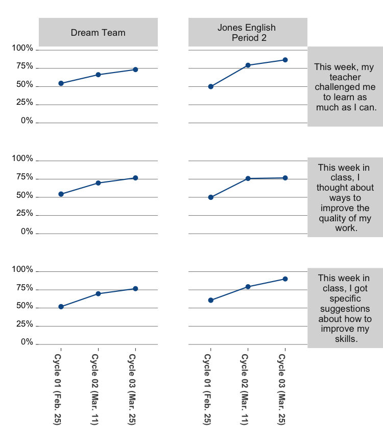

Feedback For Growth by Subpopulation  
(most recent measures)

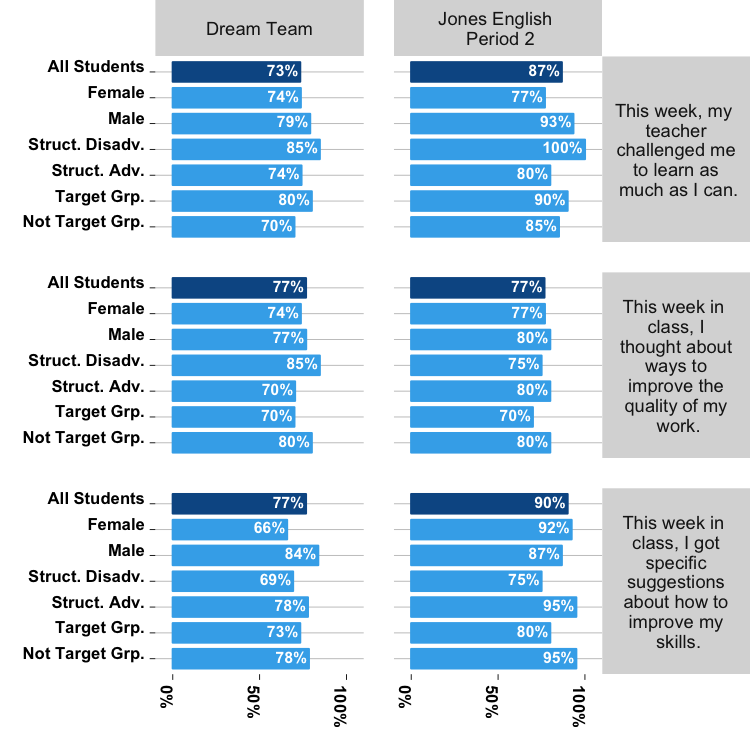

See here for more information about graphs.

### Recent Responses

*This week, my teacher challenged me to learn as much as I can.*

- thank you for letting us share our opinions

*This week in class, I got specific suggestions about how to improve my skills.*

- i liek when we get second chances to revise our work
- all good

[figure not shown]

### Learning Condition: Teacher Caring

Students engage more deeply in their work when they feel like their teachers like and care about them. To learn more, visit perts.net/conditions-teacher-caring.

+4% on average since starting: Keep it up! Overall, 11 more students now see you as more caring.

Teacher Caring over time

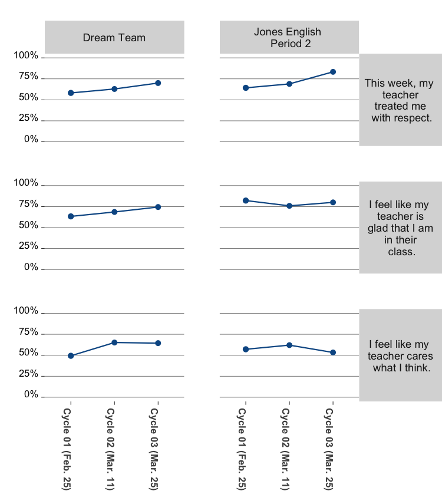

Teacher Caring by Subpopulation  
(most recent measures)

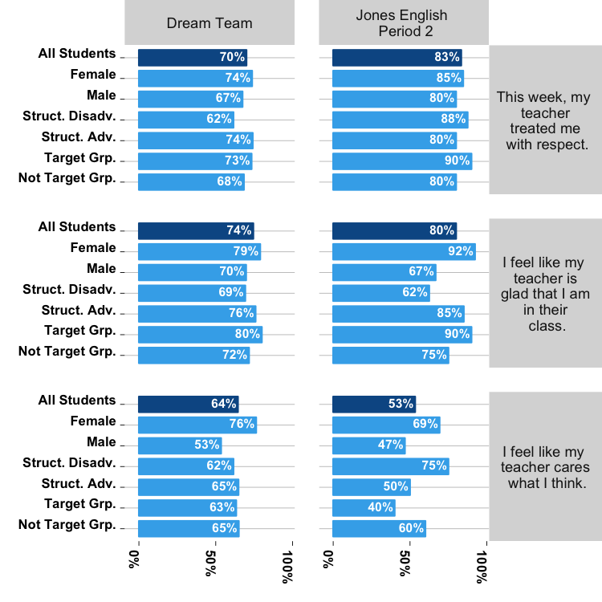

See here for more information about graphs.

### Recent Responses

*I feel like my teacher is glad that I am in their class.*

- Thanks for remembering my birthday!
- sometimes you don't call on me when i raise my hand

*I feel like my teacher cares what I think.*

- I wish you were a little more patient with us

[figure not shown]

### Learning Condition: Meaningful Work

Students are more motivated to learn when they see how class material relates to their lives outside of school. To learn more, visit perts.net/conditions-meaningful-work.

+23% on average since starting: Amazing progress! Overall, 23 more students now see this class as more meaningful.

Meaningful Work over time

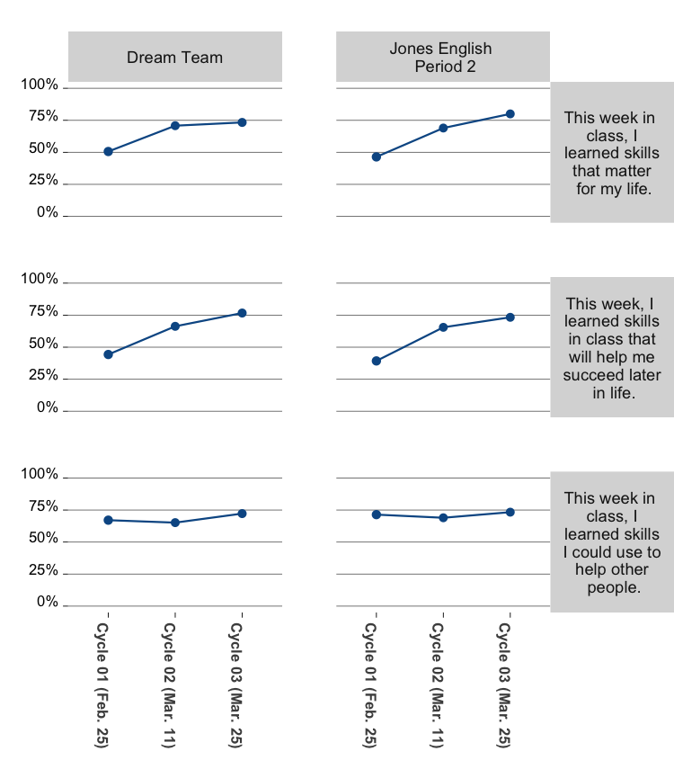

Meaningful Work by Subpopulation  
(most recent measures)

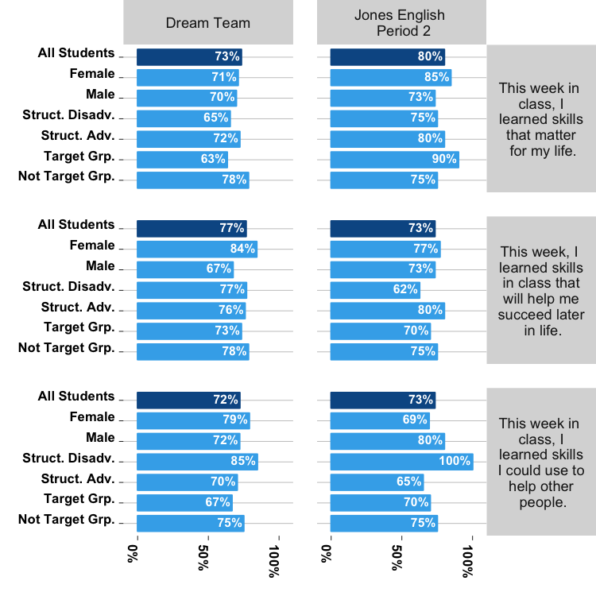

See here for more information about graphs.

### Recent Responses

*This week in class, I learned skills that matter for my life.*

- i liked when we got to talk to the scientist
- wat's the point of the stuff in chapter 3??

*This week, I learned skills in class that will help me succeed later in life.*

- I don't know why this is relevant

## Overall Recent Responses

*Is there any other feedback you'd like to share with your teacher about class this week?*

- I wish you were an easier teacher sometimes
- nothing to say ~~
- You're the best!!!

## Interpreting The Graphs

- Missing values: The gray bars marked with an “n/a” sign indicate that there were fewer than five students in a gender or ethnicity category for that response. We do not display disaggregated results when this happens so that individual student responses remain anonymous.
- The size of the dots in the time graphs reflects the proportion of responses that were present that cycle, with larger dots representing a larger proportion of responses collected that cycle.
- Races are grouped together to increase the likelihood that enough data are present to report.
- To help teachers see and address inequalities in their classrooms, this report groups student results into races that tend to be structurally advantaged (White and/or Asian American) or disadvantaged (Black, Latinx, and/or Native American) in the US education system at the national level. For more information, please see our [FAQ](https://www.perts.net/engage/faq#race-grouping). And if you want to define your own custom groups, you can define a "target group" for your team [here](https://www.perts.net/engage/faq#what-is-target-group).
- The y-axis of the graphs shows the percent of students who selected either “Agree” or “Strongly agree”. (Other response options were “Strongly disagree”, “Disagree” and “Neither agree nor disagree”.)
- If the demographic categories contain missing values, the overall mean in the bar graphs could differ from the combined means for the separate levels.
- If a classroom has fewer than 5 participants, only team-level results are shown.
- Statistical significance in the bar graphs is marked with asterisks (* p < .05, ** p < .01, *** p < .001).
- This report can be shared by forwarding the URL of this page. Links that you share will expire after 30 days.